# 方差分析

shydow

2018年12月16日

## 方差分析及anova模型拟合概述

### 方差分析的基本思想

T检验适用于两个样本均数的比较，对于多个样本的比较，如果使用T检验则会更加麻烦。使用方差分析适用于多个样本的分析。

**方差分析的目的：在H0：μ1=μ2=μ3…μk成立的条件下，通过分析各处理组均数X’之间的差别大小，推断K个总体均数之间有无差别，从而说明处理因素的效果是否存在**

**总离均差平方和（sum of squares,SS）：各变量值与总均数（X’）差值的平方和**

**组间离均差平方和：为各组样本均数（x’）与总均数（X’）差值的平方和**

**组内离均差平方和：个处理组内部观察值与其均数（x’）差值的平方和**

数理统计证明：**总的离均差平方和等于各部分离均差平方和之和**

```
        SS（组内）=SS（总）-SS（组间）
        V（组内）=N-k
        MS（组内）=SS(组内)/V（组内） -----------MS指均方，K指处理组个数，N指总的个数

        自由度：
        V（总）=N-1
        V（组间）=k-1
        V（组内）=N-k

        均方：
        MS=SS/V

        方差分析统计量：
        F=MS（组间）/MS（组内）
```

方差分析的应用条件：

```
**各样本必须是相互独立的随机样本**
**各样本来自正态分布总体**
**各样本总体方差相等，方差齐性**
```

方差分析的用途：

```
**两个或多个样本均数之间的比较，分析两个或多个因素之间的交互作用**
**回归方程的线性假设检验，多元回归分析中偏回归系数的假设检验，两样本方差齐性检验**
```

方差分析的基本思想：

```
**根据研究的目的与设计类型，将总变异中的离均差平方和SS及其自由度v分解成相应的若干部分，然 后各组相应部分的变异，再用各部分的变异与组内变异（误差）进行比较，得出统计量F值，最后根据F值得大小确定p值，做出统计推断**

例如，在总的离均差平方和（SS总）和自由度（V）将其分解为组间与组内两个部分，均方MS（组间）等于SS（组间）/V（组间，k-1）；均方SS（组内）等于SS（组内）/v（组内），进行比较MS（组间）/MS（组内）即为统计量F
```

### ANOVA模型拟合

ANOVA模型和回归方法都是广义线性模型的特例，lm()函数和aov()都可以分析ANOVA模型，两个函数的结果是等同的

```
aov()函数的格式： aov(Formula,data=dataframe)
表达式中可以使用特殊的符号：

1、~为分割符号，左边为因变量，右边为自变量，y~x1+.....xn
2、+为分割自变量
3、:表示变量的交互项，例如用A,B和AB的交互项预测，y=A+B+A:B
4、*表示所有可能的交互项，y=A*B*C----y=A+B+C+A:B+A:C+B:C
5、^表示交互项达到某个次数，y=(A+B+C)^2-----y=A+B+C+A:B+A:C+B:C
6、.表示所有自变量组合
```

一些常用的研究设计表达式：

```
* 单因素ANOVA，y~A
* 含单个协变量的单因素ANCOVA,y~x+A
* 双因素ANOVA，y~A*B
* 含连个协变量的双因素ANOVA,y~x1+x2+A:B
```

模型结果评价：

```
例如：y~A+B+A:B

A对y的影响
控制A时，B对y的影响
控制A和B的主效应时，A和B的交互效应
```

### 实例

**单因子方差分析**

1、为了了解烫伤后不同时期切对肝脏三羚酸（ATP）含量的影响，将30只雄性大鼠随机分3组，每组10只，A组为烫伤对照组，B组为烫伤后24小时（休克期）切除组；C组为烫伤后96小时（非休克期）切除组，全部动物统一在196小时后处死测量肝脏ATP含量，结果如表，请检验3组老鼠肝脏ATP含量有无差别。

```r
library(multcomp)
```

```r
library(gplots)
example8_1<-read.table('F:\\课件\\资源\\《R语言统计分析与应用》配套程序\\第八章\\example8_1.csv',header=TRUE,sep=',')
example8_1$group<-as.factor(example8_1$group)   #需要将数字转为因子型变量
attach(example8_1)
table(group)
```

```
## group
##  1  2  3
## 10 10 10
```

```r
aggregate(atp,by=list(group=group),mean)
```

```
##   group      x
## 1     1  8.043
## 2     2 12.755
## 3     3  9.249
```

```r
aggregate(atp,by=list(group=group),sd)
```

```
##   group        x
## 1     1 1.808075
## 2     2 2.790047
## 3     3 1.224277
```

```r
fit<-aov(atp~group)
summary(fit)
```

```
##             Df Sum Sq Mean Sq F value   Pr(>F)
## group        2  119.8   59.92   14.32 5.76e-05 ***
## Residuals   27  113.0    4.18
## ---
## Signif. codes:  0 '***' 0.001 '**' 0.01 '*' 0.05 '.' 0.1 ' ' 1
```

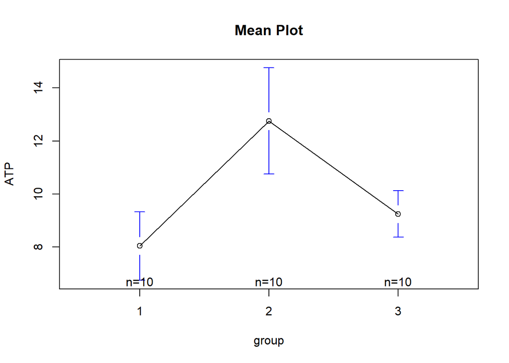

```r
#这里得出的p值小于0.05，故F检验非常显著，所以ATP含量差异具有统计学意义

plotmeans(atp~group,xlab = 'group',ylab = 'ATP',main='Mean Plot')
```

```r
detach(example8_1)        #TukeyHSD()函数提供各组均值差异的成对检验
TukeyHSD(fit)
```

```
##   Tukey multiple comparisons of means
##     95% family-wise confidence level
##
## Fit: aov(formula = atp ~ group)
##
## $group
##       diff       lwr       upr     p adj
## 2-1  4.712  2.443877  6.980123 0.0000588
## 3-1  1.206 -1.062123  3.474123 0.3975104
## 3-2 -3.506 -5.774123 -1.237877 0.0019270
```

2、调查得到成年男子各年龄段淋巴细胞转化率如下，问各组淋巴细胞转化率均数是否有显著性差异？

```
11--20岁  58 61 62 61 63 70 70 68 74 78 80 76
21--60岁  54 57 58 57 60 61 63 64 66 62
61--80岁  42 56 57 54 60 57 53 51
非平衡数据的处理
```

```r
example8_2<-read.csv('F:\\课件\\资源\\《R语言统计分析与应用》配套程序\\第八章\\example8_2.csv',header=TRUE)
attach(example8_2)
table(group)
```

```
## group
## 11-20 21-60 61-80
##    12    10     8
```

```r
aggregate(x,by=list(group),mean)
```

```
##   Group.1        x
## 1   11-20 68.41667
## 2   21-60 60.20000
## 3   61-80 53.75000
```

```r
aggregate(x,by=list(group),sd)
```

```
##   Group.1        x
## 1   11-20 7.440165
## 2   21-60 3.705851
## 3   61-80 5.496752
```

```r
fit1<-aov(x~group)
summary(fit1)
```

```
##             Df Sum Sq Mean Sq F value   Pr(>F)
## group        2   1069   534.7   15.29 3.62e-05 ***
## Residuals   27    944    35.0
## ---
## Signif. codes:  0 '***' 0.001 '**' 0.01 '*' 0.05 '.' 0.1 ' ' 1
```

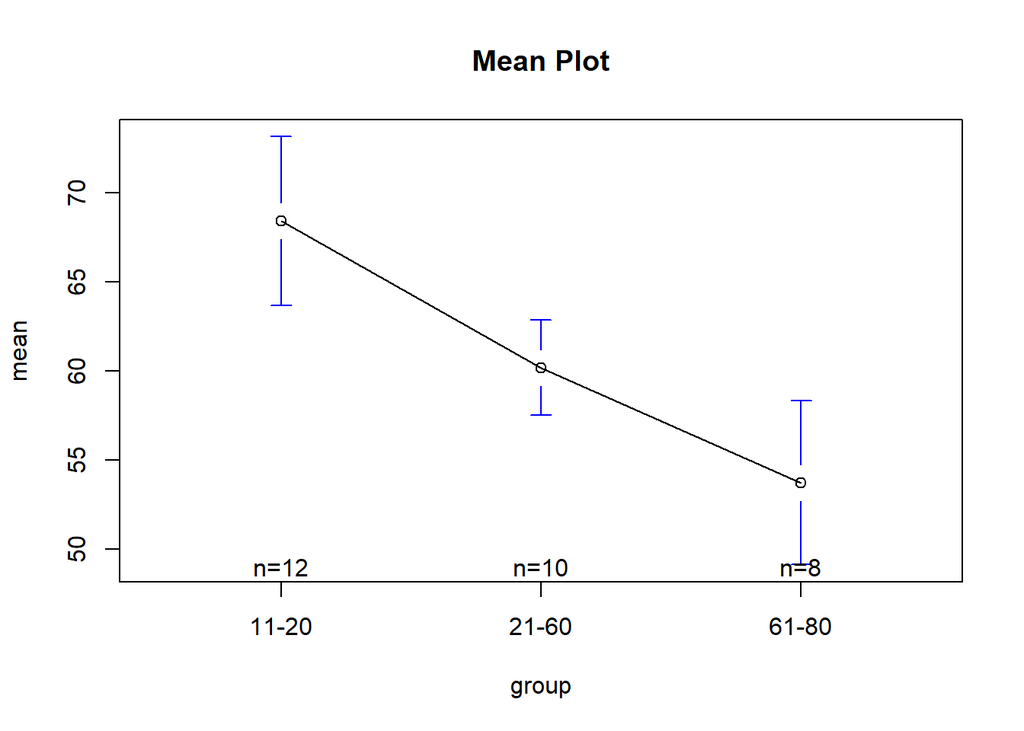

```r
plotmeans(x~group,xlab='group',ylab = 'mean',main='Mean Plot')
```

```r
detach(example8_2)
TukeyHSD(fit1)
```

```
##   Tukey multiple comparisons of means
##     95% family-wise confidence level
##
## Fit: aov(formula = x ~ group)
##
## $group
##                   diff       lwr        upr     p adj
## 21-60-11-20  -8.216667 -14.49405 -1.9392875 0.0084892
## 61-80-11-20 -14.666667 -21.35838 -7.9749580 0.0000276
## 61-80-21-60  -6.450000 -13.40423  0.5042276 0.0729766
```